# ANCOVA test for matematica (engajamento no matematica)

Geiser C. Challco geiser@alumni.usp.br

- Descriptive Statistics of Initial Data
- Checking of Assumptions
  - Assumption: Normality distribution of data
  - Assumption: Homogeneity of data distribution
- Computation of ANCOVA test and Pairwise Comparison
  - ANCOVA tests for one factor
  - ANCOVA tests for two factors
  - ANCOVA tests for grupo=“WordGen”
  - Pairwise comparisons for one factor
    - factor: **grupo**
    - factor: **genero**
    - factor: **idade**
    - factor: **zona.participante**
    - factor: **escola**
    - factor: **zona.escola**
  - Pairwise comparisons for two factors
    - factores: **grupo:genero**
    - factores: **grupo:idade**
    - factores: **grupo:zona.participante**
    - factores: **grupo:escola**
    - factores: **grupo:zona.escola**
  - Pairwise comparisons for grupo=“Experimental”
    - factores: **grupo=“Experimental”:monitor**
    - factores: **grupo=“Experimental”:monitor.genero**
    - factores: **grupo=“Experimental”:monitor.area**
    - factores: **grupo=“Experimental”:monitor.formacao**
    - factores: **grupo=“Experimental”:monitor.experiencia**

**NOTE**

- Teste ANCOVA para determinar se houve diferenças significativas em referência ao engajamento no matematica (medido como estado de fluxo).
- ANCOVA test to determine whether there were significant differences in reference to engagement in matematica (measured as flow state).

# Descriptive Statistics of Initial Data

| grupo | genero | idade | zona.participante | escola | zona.escola | variable | n | mean | median | min | max | sd | se | ci | iqr |
| --- | --- | --- | --- | --- | --- | --- | --- | --- | --- | --- | --- | --- | --- | --- | --- |
| Controle | F |  |  |  |  | fss.matematica | 60 | 3.401 | 3.389 | 2.000 | 4.333 | 0.522 | 0.067 | 0.135 | 0.778 |
| Controle | M |  |  |  |  | fss.matematica | 65 | 3.363 | 3.333 | 2.444 | 4.444 | 0.482 | 0.060 | 0.120 | 0.556 |
| WordGen | F |  |  |  |  | fss.matematica | 53 | 3.478 | 3.444 | 2.444 | 4.444 | 0.540 | 0.074 | 0.149 | 0.889 |
| WordGen | M |  |  |  |  | fss.matematica | 63 | 3.449 | 3.444 | 1.778 | 4.714 | 0.636 | 0.080 | 0.160 | 0.889 |
| Controle | F |  |  |  |  | dfs.matematica | 60 | 3.510 | 3.556 | 2.000 | 4.556 | 0.584 | 0.075 | 0.151 | 0.694 |
| Controle | M |  |  |  |  | dfs.matematica | 65 | 3.546 | 3.556 | 2.444 | 4.556 | 0.483 | 0.060 | 0.120 | 0.667 |
| WordGen | F |  |  |  |  | dfs.matematica | 53 | 3.604 | 3.667 | 2.333 | 4.857 | 0.577 | 0.079 | 0.159 | 0.778 |
| WordGen | M |  |  |  |  | dfs.matematica | 63 | 3.447 | 3.444 | 1.667 | 4.556 | 0.558 | 0.070 | 0.141 | 0.833 |
| Controle |  | 10y |  |  |  | fss.matematica | 24 | 3.435 | 3.444 | 2.444 | 4.444 | 0.508 | 0.104 | 0.214 | 0.500 |
| Controle |  | 11y |  |  |  | fss.matematica | 67 | 3.374 | 3.333 | 2.000 | 4.444 | 0.504 | 0.062 | 0.123 | 0.556 |
| Controle |  | 12y |  |  |  | fss.matematica | 18 | 3.474 | 3.333 | 2.778 | 4.333 | 0.509 | 0.120 | 0.253 | 0.667 |
| Controle |  | 13y |  |  |  | fss.matematica | 7 | 3.058 | 2.889 | 2.778 | 3.625 | 0.320 | 0.121 | 0.296 | 0.389 |
| Controle |  | 14y |  |  |  | fss.matematica | 1 | 3.556 | 3.556 | 3.556 | 3.556 |  |  |  | 0.000 |
| Controle |  | 15y |  |  |  | fss.matematica | 1 | 2.444 | 2.444 | 2.444 | 2.444 |  |  |  | 0.000 |
| Controle |  | 16y |  |  |  | fss.matematica | 1 | 3.000 | 3.000 | 3.000 | 3.000 |  |  |  | 0.000 |
| Controle |  |  |  |  |  | fss.matematica | 6 | 3.537 | 3.611 | 3.000 | 4.222 | 0.484 | 0.198 | 0.508 | 0.667 |
| WordGen |  | 10y |  |  |  | fss.matematica | 22 | 3.222 | 3.278 | 1.778 | 4.444 | 0.640 | 0.136 | 0.284 | 0.556 |
| WordGen |  | 11y |  |  |  | fss.matematica | 71 | 3.585 | 3.667 | 1.889 | 4.714 | 0.553 | 0.066 | 0.131 | 0.722 |
| WordGen |  | 12y |  |  |  | fss.matematica | 14 | 3.355 | 3.444 | 2.444 | 4.111 | 0.525 | 0.140 | 0.303 | 0.861 |
| WordGen |  | 13y |  |  |  | fss.matematica | 6 | 3.000 | 3.111 | 1.889 | 3.778 | 0.625 | 0.255 | 0.655 | 0.306 |
| WordGen |  | 14y |  |  |  | fss.matematica | 1 | 4.444 | 4.444 | 4.444 | 4.444 |  |  |  | 0.000 |
| WordGen |  |  |  |  |  | fss.matematica | 2 | 3.389 | 3.389 | 3.333 | 3.444 | 0.079 | 0.056 | 0.706 | 0.056 |
| Controle |  | 10y |  |  |  | dfs.matematica | 24 | 3.427 | 3.410 | 2.222 | 4.556 | 0.519 | 0.106 | 0.219 | 0.646 |
| Controle |  | 11y |  |  |  | dfs.matematica | 67 | 3.588 | 3.667 | 2.000 | 4.556 | 0.529 | 0.065 | 0.129 | 0.667 |
| Controle |  | 12y |  |  |  | dfs.matematica | 18 | 3.560 | 3.646 | 2.750 | 4.333 | 0.484 | 0.114 | 0.241 | 0.722 |
| Controle |  | 13y |  |  |  | dfs.matematica | 7 | 3.683 | 3.778 | 3.000 | 4.556 | 0.519 | 0.196 | 0.480 | 0.556 |
| Controle |  | 14y |  |  |  | dfs.matematica | 1 | 3.444 | 3.444 | 3.444 | 3.444 |  |  |  | 0.000 |
| Controle |  | 15y |  |  |  | dfs.matematica | 1 | 2.444 | 2.444 | 2.444 | 2.444 |  |  |  | 0.000 |
| Controle |  | 16y |  |  |  | dfs.matematica | 1 | 3.444 | 3.444 | 3.444 | 3.444 |  |  |  | 0.000 |
| Controle |  |  |  |  |  | dfs.matematica | 6 | 3.222 | 3.000 | 2.667 | 4.556 | 0.692 | 0.283 | 0.726 | 0.417 |
| WordGen |  | 10y |  |  |  | dfs.matematica | 22 | 3.439 | 3.444 | 2.333 | 4.556 | 0.565 | 0.120 | 0.250 | 0.556 |
| WordGen |  | 11y |  |  |  | dfs.matematica | 71 | 3.576 | 3.667 | 2.333 | 4.857 | 0.552 | 0.066 | 0.131 | 0.778 |
| WordGen |  | 12y |  |  |  | dfs.matematica | 14 | 3.392 | 3.333 | 1.667 | 4.333 | 0.694 | 0.185 | 0.400 | 0.611 |
| WordGen |  | 13y |  |  |  | dfs.matematica | 6 | 3.389 | 3.556 | 2.556 | 4.000 | 0.591 | 0.241 | 0.620 | 0.833 |
| WordGen |  | 14y |  |  |  | dfs.matematica | 1 | 3.000 | 3.000 | 3.000 | 3.000 |  |  |  | 0.000 |
| WordGen |  |  |  |  |  | dfs.matematica | 2 | 3.889 | 3.889 | 3.889 | 3.889 | 0.000 | 0.000 | 0.000 | 0.000 |
| Controle |  |  | Urbana |  |  | fss.matematica | 54 | 3.381 | 3.389 | 2.444 | 4.444 | 0.514 | 0.070 | 0.140 | 0.667 |
| Controle |  |  | Rural |  |  | fss.matematica | 43 | 3.376 | 3.333 | 2.000 | 4.444 | 0.464 | 0.071 | 0.143 | 0.535 |
| Controle |  |  |  |  |  | fss.matematica | 28 | 3.390 | 3.556 | 2.444 | 4.333 | 0.544 | 0.103 | 0.211 | 0.917 |
| WordGen |  |  | Urbana |  |  | fss.matematica | 43 | 3.351 | 3.333 | 1.889 | 4.714 | 0.647 | 0.099 | 0.199 | 1.000 |
| WordGen |  |  | Rural |  |  | fss.matematica | 48 | 3.481 | 3.667 | 1.778 | 4.444 | 0.562 | 0.081 | 0.163 | 0.667 |
| WordGen |  |  |  |  |  | fss.matematica | 25 | 3.618 | 3.667 | 2.556 | 4.556 | 0.529 | 0.106 | 0.218 | 0.889 |
| Controle |  |  | Urbana |  |  | dfs.matematica | 54 | 3.437 | 3.444 | 2.222 | 4.333 | 0.500 | 0.068 | 0.136 | 0.549 |
| Controle |  |  | Rural |  |  | dfs.matematica | 43 | 3.555 | 3.556 | 2.000 | 4.556 | 0.594 | 0.091 | 0.183 | 0.889 |
| Controle |  |  |  |  |  | dfs.matematica | 28 | 3.666 | 3.667 | 2.778 | 4.556 | 0.472 | 0.089 | 0.183 | 0.583 |
| WordGen |  |  | Urbana |  |  | dfs.matematica | 43 | 3.385 | 3.333 | 1.667 | 4.857 | 0.632 | 0.096 | 0.195 | 0.778 |
| WordGen |  |  | Rural |  |  | dfs.matematica | 48 | 3.561 | 3.500 | 2.667 | 4.556 | 0.543 | 0.078 | 0.158 | 0.806 |
| WordGen |  |  |  |  |  | dfs.matematica | 25 | 3.667 | 3.667 | 2.444 | 4.333 | 0.467 | 0.093 | 0.193 | 0.444 |
| Controle |  |  |  | E1 |  | fss.matematica | 12 | 3.120 | 3.167 | 2.444 | 4.222 | 0.516 | 0.149 | 0.328 | 0.694 |
| Controle |  |  |  | E2 |  | fss.matematica | 23 | 3.314 | 3.222 | 2.444 | 4.333 | 0.479 | 0.100 | 0.207 | 0.722 |
| Controle |  |  |  | E3 |  | fss.matematica | 15 | 3.378 | 3.333 | 2.000 | 3.889 | 0.440 | 0.114 | 0.244 | 0.333 |
| Controle |  |  |  | E4 |  | fss.matematica | 16 | 3.370 | 3.278 | 2.778 | 4.000 | 0.361 | 0.090 | 0.192 | 0.524 |
| Controle |  |  |  | E5 |  | fss.matematica | 48 | 3.455 | 3.444 | 2.444 | 4.444 | 0.563 | 0.081 | 0.163 | 0.806 |
| Controle |  |  |  | E6 |  | fss.matematica | 11 | 3.505 | 3.556 | 2.444 | 4.000 | 0.462 | 0.139 | 0.310 | 0.556 |
| WordGen |  |  |  | E1 |  | fss.matematica | 10 | 3.805 | 3.889 | 2.667 | 4.714 | 0.629 | 0.199 | 0.450 | 0.778 |
| WordGen |  |  |  | E2 |  | fss.matematica | 24 | 3.307 | 3.333 | 1.889 | 4.444 | 0.551 | 0.112 | 0.232 | 0.597 |
| WordGen |  |  |  | E3 |  | fss.matematica | 15 | 3.302 | 3.333 | 2.556 | 4.111 | 0.473 | 0.122 | 0.262 | 0.667 |
| WordGen |  |  |  | E4 |  | fss.matematica | 9 | 3.664 | 3.778 | 2.778 | 4.222 | 0.499 | 0.166 | 0.384 | 0.333 |
| WordGen |  |  |  | E5 |  | fss.matematica | 47 | 3.426 | 3.444 | 1.778 | 4.667 | 0.650 | 0.095 | 0.191 | 1.000 |
| WordGen |  |  |  | E6 |  | fss.matematica | 11 | 3.697 | 3.778 | 3.000 | 4.333 | 0.453 | 0.137 | 0.304 | 0.833 |
| Controle |  |  |  | E1 |  | dfs.matematica | 12 | 3.074 | 3.222 | 2.222 | 3.556 | 0.445 | 0.129 | 0.283 | 0.611 |
| Controle |  |  |  | E2 |  | dfs.matematica | 23 | 3.570 | 3.667 | 2.444 | 4.333 | 0.438 | 0.091 | 0.189 | 0.604 |
| Controle |  |  |  | E3 |  | dfs.matematica | 15 | 3.731 | 3.889 | 2.750 | 4.556 | 0.626 | 0.162 | 0.346 | 0.944 |
| Controle |  |  |  | E4 |  | dfs.matematica | 16 | 3.583 | 3.444 | 3.222 | 4.556 | 0.362 | 0.090 | 0.193 | 0.361 |
| Controle |  |  |  | E5 |  | dfs.matematica | 48 | 3.496 | 3.578 | 2.000 | 4.556 | 0.582 | 0.084 | 0.169 | 0.806 |
| Controle |  |  |  | E6 |  | dfs.matematica | 11 | 3.727 | 3.778 | 3.000 | 4.333 | 0.405 | 0.122 | 0.272 | 0.333 |
| WordGen |  |  |  | E1 |  | dfs.matematica | 10 | 3.358 | 3.361 | 2.444 | 4.111 | 0.564 | 0.178 | 0.404 | 0.792 |
| WordGen |  |  |  | E2 |  | dfs.matematica | 24 | 3.417 | 3.556 | 1.667 | 4.111 | 0.576 | 0.118 | 0.243 | 0.694 |
| WordGen |  |  |  | E3 |  | dfs.matematica | 15 | 3.584 | 3.333 | 2.750 | 4.556 | 0.643 | 0.166 | 0.356 | 1.167 |
| WordGen |  |  |  | E4 |  | dfs.matematica | 9 | 3.781 | 3.778 | 3.111 | 4.444 | 0.478 | 0.159 | 0.367 | 0.917 |
| WordGen |  |  |  | E5 |  | dfs.matematica | 47 | 3.477 | 3.444 | 2.333 | 4.857 | 0.574 | 0.084 | 0.169 | 0.833 |
| WordGen |  |  |  | E6 |  | dfs.matematica | 11 | 3.758 | 3.667 | 2.778 | 4.333 | 0.460 | 0.139 | 0.309 | 0.500 |
| Controle |  |  |  |  | Urbana | fss.matematica | 83 | 3.367 | 3.333 | 2.444 | 4.444 | 0.541 | 0.059 | 0.118 | 0.722 |
| Controle |  |  |  |  | Rural | fss.matematica | 42 | 3.408 | 3.389 | 2.000 | 4.000 | 0.411 | 0.063 | 0.128 | 0.444 |
| WordGen |  |  |  |  | Urbana | fss.matematica | 81 | 3.438 | 3.444 | 1.778 | 4.714 | 0.630 | 0.070 | 0.139 | 1.000 |
| WordGen |  |  |  |  | Rural | fss.matematica | 35 | 3.519 | 3.667 | 2.556 | 4.333 | 0.498 | 0.084 | 0.171 | 0.667 |
| Controle |  |  |  |  | Urbana | dfs.matematica | 83 | 3.456 | 3.556 | 2.000 | 4.556 | 0.546 | 0.060 | 0.119 | 0.778 |
| Controle |  |  |  |  | Rural | dfs.matematica | 42 | 3.674 | 3.667 | 2.750 | 4.556 | 0.476 | 0.073 | 0.148 | 0.639 |
| WordGen |  |  |  |  | Urbana | dfs.matematica | 81 | 3.445 | 3.444 | 1.667 | 4.857 | 0.568 | 0.063 | 0.126 | 0.778 |
| WordGen |  |  |  |  | Rural | dfs.matematica | 35 | 3.689 | 3.667 | 2.750 | 4.556 | 0.543 | 0.092 | 0.187 | 0.889 |

# Checking of Assumptions

## Assumption: Normality distribution of data

| var | n | skewness | kurtosis | symmetry | statistic | method | p | p.signif | normality |
| --- | --- | --- | --- | --- | --- | --- | --- | --- | --- |
| fss.matematica | 241 | -0.0645418 | 0.1335094 | YES | 0.6850632 | D’Agostino | 0.7099707 | ns | - |
| fss.matematica | 233 | -0.1258511 | 0.2247059 | YES | 1.5770035 | D’Agostino | 0.4545253 | ns | - |
| fss.matematica | 188 | 0.0210581 | 0.4230608 | YES | 1.8946908 | D’Agostino | 0.3877690 | ns | QQ |
| fss.matematica | 241 | -0.2361354 | 0.0587574 | YES | 2.5804695 | D’Agostino | 0.2752062 | ns | - |
| fss.matematica | 241 | -0.0585116 | 0.0952570 | YES | 0.5060668 | D’Agostino | 0.7764420 | ns | - |

## Assumption: Homogeneity of data distribution

| var | method | formula | n | DFn.df1 | DFd.df2 | statistic | p | p.signif |
| --- | --- | --- | --- | --- | --- | --- | --- | --- |
| fss.matematica | Levene’s test | `.res`~`grupo`*`genero` | 241 | 3 | 237 | 0.5963206 | 0.6179874 | ns |
| fss.matematica | Anova’s slopes | `.res`~`grupo`*`genero` | 241 | 3 | 233 | 0.4570000 | 0.7130000 | ns |
| fss.matematica | Levene’s test | `.res`~`grupo`*`idade` | 233 | 11 | 221 | 0.8718677 | 0.5687111 | ns |
| fss.matematica | Anova’s slopes | `.res`~`grupo`*`idade` | 233 | 7 | 213 | 1.3650000 | 0.2220000 | ns |
| fss.matematica | Levene’s test | `.res`~`grupo`*`zona.participante` | 188 | 3 | 184 | 1.7713047 | 0.1541948 | ns |
| fss.matematica | Anova’s slopes | `.res`~`grupo`*`zona.participante` | 188 | 3 | 180 | 0.6290000 | 0.5970000 | ns |
| fss.matematica | Levene’s test | `.res`~`grupo`*`escola` | 241 | 11 | 229 | 1.3160536 | 0.2162818 | ns |
| fss.matematica | Anova’s slopes | `.res`~`grupo`*`escola` | 241 | 11 | 217 | 1.7810000 | 0.0590000 | ns |
| fss.matematica | Levene’s test | `.res`~`grupo`*`zona.escola` | 241 | 3 | 237 | 2.3017914 | 0.0778277 | ns |
| fss.matematica | Anova’s slopes | `.res`~`grupo`*`zona.escola` | 241 | 3 | 233 | 0.8380000 | 0.4740000 | ns |

# Computation of ANCOVA test and Pairwise Comparison

## ANCOVA tests for one factor

|  | Effect | DFn | DFd | SSn | SSd | F | p | ges | p<.05 |
| --- | --- | --- | --- | --- | --- | --- | --- | --- | --- |
| 1 | dfs.matematica | 1 | 238 | 8.169 | 63.134 | 30.795 | <0.001 | 0.115 | * |
| 2 | grupo | 1 | 238 | 0.433 | 63.134 | 1.632 | 0.203 | 0.007 |  |
| 4 | genero | 1 | 238 | 0.009 | 63.558 | 0.035 | 0.853 | 0.000 |  |
| 6 | idade | 6 | 225 | 3.904 | 58.278 | 2.512 | 0.023 | 0.063 | * |
| 8 | zona.participante | 1 | 185 | 0.018 | 50.267 | 0.067 | 0.796 | 0.000 |  |
| 10 | escola | 5 | 234 | 1.609 | 61.958 | 1.215 | 0.303 | 0.025 |  |
| 12 | zona.escola | 1 | 238 | 0.024 | 63.543 | 0.088 | 0.766 | 0.000 |  |

## ANCOVA tests for two factors

|  | Effect | DFn | DFd | SSn | SSd | F | p | ges | p<.05 |
| --- | --- | --- | --- | --- | --- | --- | --- | --- | --- |
| 1 | dfs.matematica | 1 | 236 | 8.195 | 63.040 | 30.678 | <0.001 | 0.115 | * |
| 4 | grupo:genero | 1 | 236 | 0.081 | 63.040 | 0.305 | 0.581 | 0.001 |  |
| 8 | grupo:idade | 4 | 220 | 2.265 | 55.561 | 2.242 | 0.065 | 0.039 |  |
| 12 | grupo:zona.participante | 1 | 183 | 0.161 | 50.018 | 0.587 | 0.444 | 0.003 |  |
| 16 | grupo:escola | 5 | 228 | 1.929 | 59.552 | 1.477 | 0.198 | 0.031 |  |
| 20 | grupo:zona.escola | 1 | 236 | 0.013 | 63.104 | 0.048 | 0.827 | 0.000 |  |

## ANCOVA tests for grupo=“WordGen”

|  | Effect | DFn | DFd | SSn | SSd | F | p | ges | p<.05 |
| --- | --- | --- | --- | --- | --- | --- | --- | --- | --- |
| 1 | dfs.matematica | 1 | 101 | 5.060 | 27.135 | 18.834 | <0.001 | 0.157 | * |
| 2 | monitor | 9 | 101 | 3.989 | 27.135 | 1.650 | 0.111 | 0.128 |  |
| 4 | monitor.genero | 1 | 109 | 0.261 | 30.863 | 0.922 | 0.339 | 0.008 |  |
| 6 | monitor.area | 8 | 102 | 3.988 | 27.137 | 1.874 | 0.072 | 0.128 |  |
| 8 | monitor.formacao | 2 | 108 | 0.080 | 31.044 | 0.139 | 0.87 | 0.003 |  |
| 10 | monitor.experiencia | 1 | 109 | 0.592 | 30.532 | 2.114 | 0.149 | 0.019 |  |

## Pairwise comparisons for one factor

### factor: **grupo**

| var | grupo | n | M (pre) | SE (pre) | M (unadj) | SE (unadj) | M (adj) | SE (adj) |
| --- | --- | --- | --- | --- | --- | --- | --- | --- |
| fss.matematica | Controle | 125 | 3.529 | 0.048 | 3.381 | 0.045 | 3.379 | 0.046 |
| fss.matematica | WordGen | 116 | 3.518 | 0.053 | 3.462 | 0.055 | 3.464 | 0.048 |

| .y. | group1 | group2 | estimate | conf.low | conf.high | se | statistic | p | p.adj | p.adj.signif |
| --- | --- | --- | --- | --- | --- | --- | --- | --- | --- | --- |
| fss.matematica | Controle | WordGen | -0.085 | -0.216 | 0.046 | 0.066 | -1.278 | 0.203 | 0.203 | ns |
| dfs.matematica | Controle | WordGen | 0.011 | -0.129 | 0.150 | 0.071 | 0.150 | 0.881 | 0.881 | ns |

| .y. | grupo | group1 | group2 | estimate | conf.low | conf.high | se | statistic | p | p.adj | p.adj.signif |
| --- | --- | --- | --- | --- | --- | --- | --- | --- | --- | --- | --- |
| flow.matematica | Controle | pre | pos | 0.148 | 0.012 | 0.284 | 0.069 | 2.133 | 0.033 | 0.033 | * |
| flow.matematica | WordGen | pre | pos | 0.056 | -0.085 | 0.197 | 0.072 | 0.778 | 0.437 | 0.437 | ns |

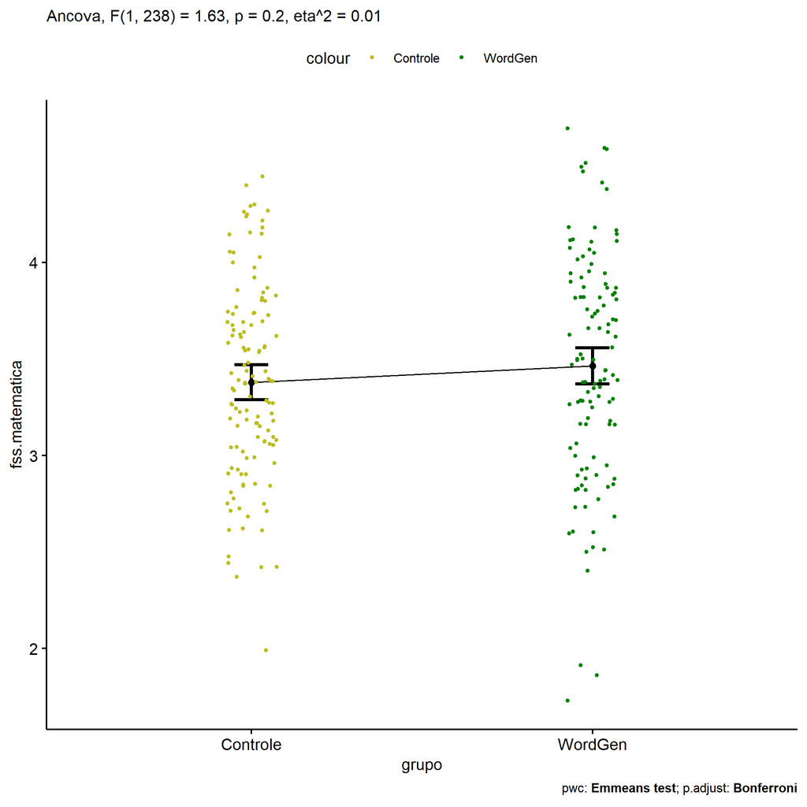

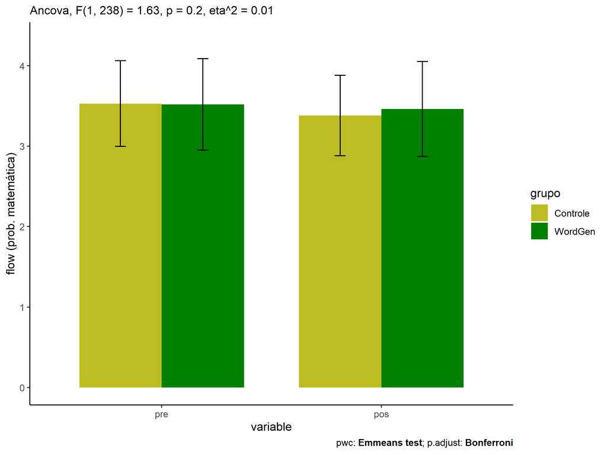

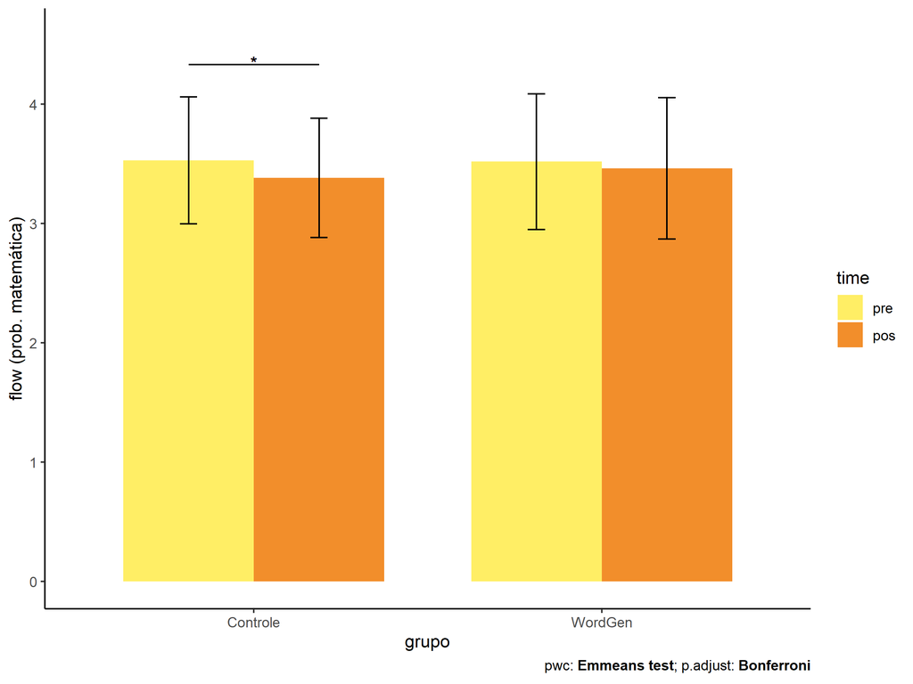

### factor: **genero**

| var | genero | n | M (pre) | SE (pre) | M (unadj) | SE (unadj) | M (adj) | SE (adj) |
| --- | --- | --- | --- | --- | --- | --- | --- | --- |
| fss.matematica | F | 113 | 3.554 | 0.055 | 3.437 | 0.05 | 3.427 | 0.049 |
| fss.matematica | M | 128 | 3.497 | 0.046 | 3.405 | 0.05 | 3.414 | 0.046 |

| .y. | group1 | group2 | estimate | conf.low | conf.high | se | statistic | p | p.adj | p.adj.signif |
| --- | --- | --- | --- | --- | --- | --- | --- | --- | --- | --- |
| fss.matematica | F | M | 0.012 | -0.119 | 0.144 | 0.067 | 0.186 | 0.853 | 0.853 | ns |
| dfs.matematica | F | M | 0.057 | -0.083 | 0.197 | 0.071 | 0.803 | 0.422 | 0.422 | ns |

| .y. | genero | group1 | group2 | estimate | conf.low | conf.high | se | statistic | p | p.adj | p.adj.signif |
| --- | --- | --- | --- | --- | --- | --- | --- | --- | --- | --- | --- |
| flow.matematica | F | pre | pos | 0.117 | -0.026 | 0.261 | 0.073 | 1.607 | 0.109 | 0.109 | ns |
| flow.matematica | M | pre | pos | 0.092 | -0.043 | 0.226 | 0.069 | 1.338 | 0.182 | 0.182 | ns |

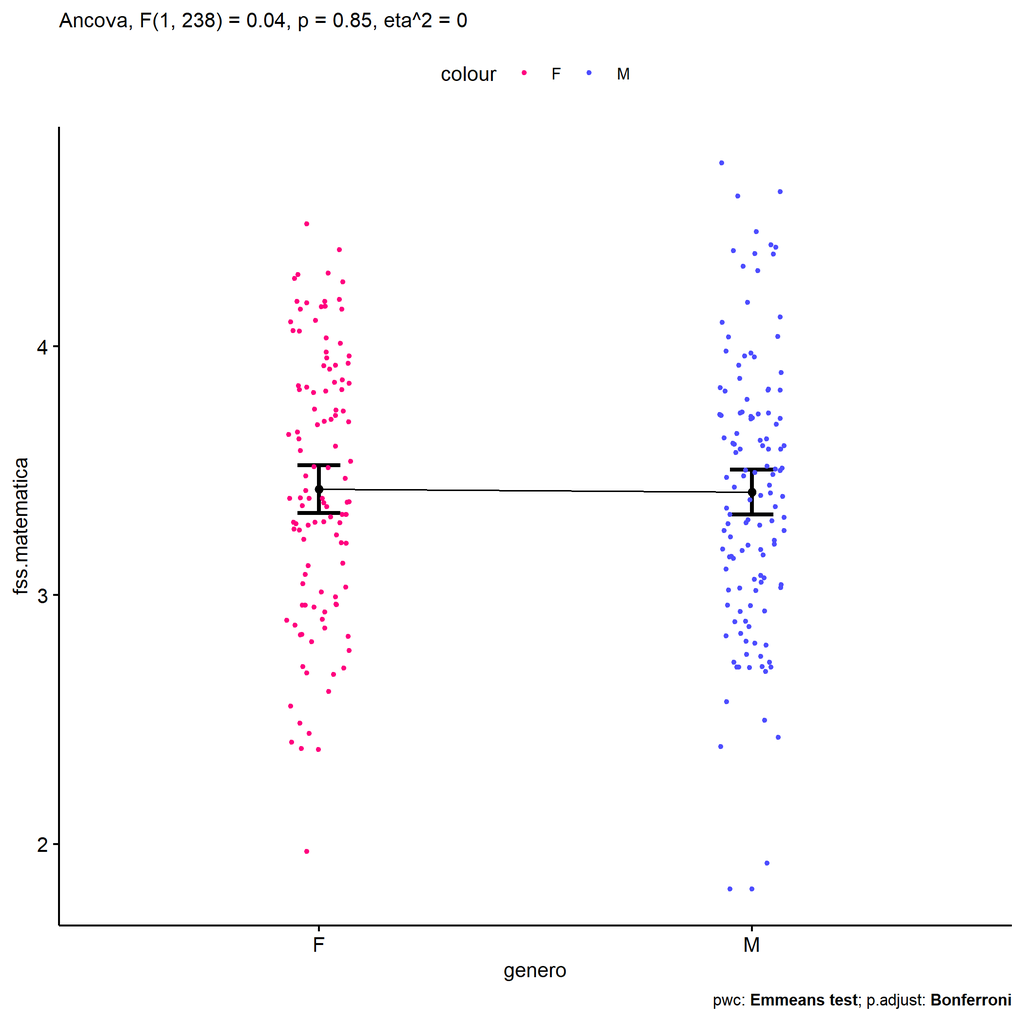

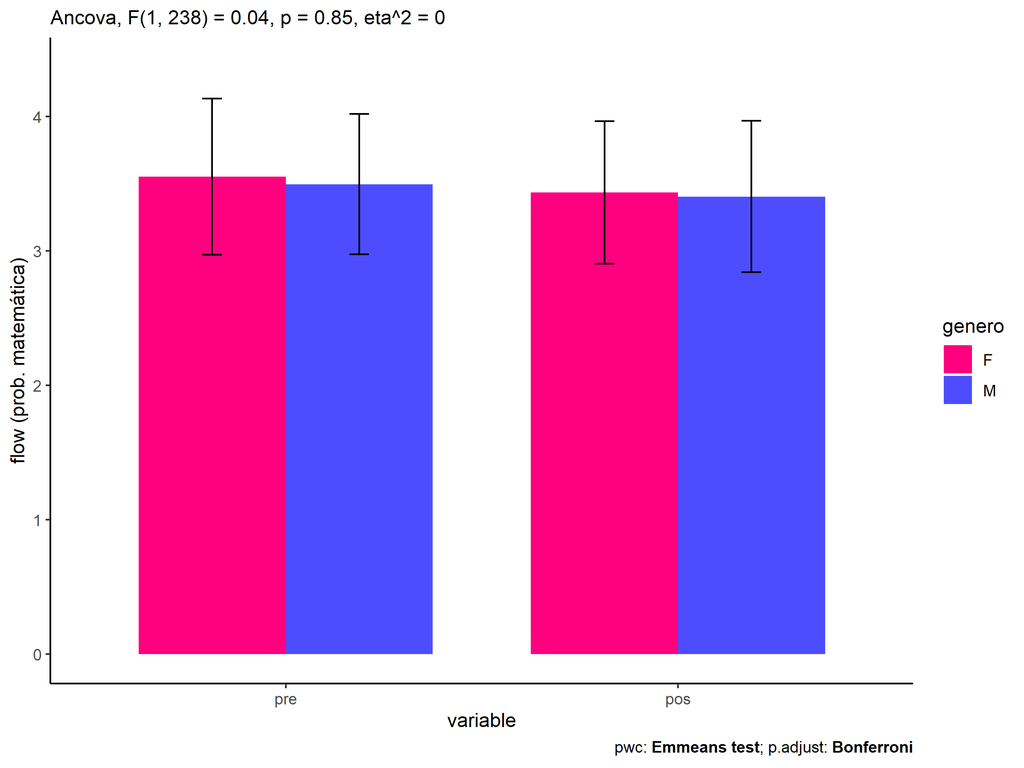

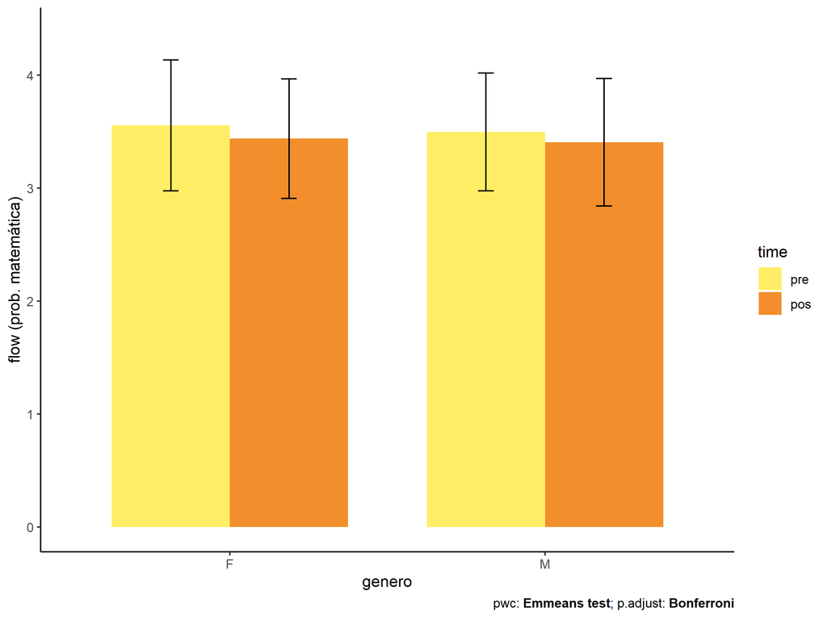

### factor: **idade**

| var | idade | n | M (pre) | SE (pre) | M (unadj) | SE (unadj) | M (adj) | SE (adj) |
| --- | --- | --- | --- | --- | --- | --- | --- | --- |
| fss.matematica | 10y | 46 | 3.433 | 0.079 | 3.333 | 0.085 | 3.368 | 0.075 |
| fss.matematica | 11y | 138 | 3.581 | 0.046 | 3.483 | 0.046 | 3.467 | 0.043 |
| fss.matematica | 12y | 32 | 3.487 | 0.103 | 3.422 | 0.090 | 3.439 | 0.090 |
| fss.matematica | 13y | 13 | 3.547 | 0.153 | 3.031 | 0.128 | 3.027 | 0.141 |

| .y. | group1 | group2 | estimate | conf.low | conf.high | se | statistic | p | p.adj | p.adj.signif |
| --- | --- | --- | --- | --- | --- | --- | --- | --- | --- | --- |
| fss.matematica | 10y | 11y | -0.099 | -0.270 | 0.072 | 0.087 | -1.137 | 0.257 | 1.000 | ns |
| fss.matematica | 10y | 12y | -0.070 | -0.301 | 0.160 | 0.117 | -0.600 | 0.549 | 1.000 | ns |
| fss.matematica | 10y | 13y | 0.341 | 0.026 | 0.656 | 0.160 | 2.136 | 0.034 | 0.202 | ns |
| fss.matematica | 11y | 12y | 0.029 | -0.168 | 0.225 | 0.100 | 0.288 | 0.774 | 1.000 | ns |
| fss.matematica | 11y | 13y | 0.440 | 0.150 | 0.730 | 0.147 | 2.986 | 0.003 | 0.019 | * |
| fss.matematica | 12y | 13y | 0.411 | 0.082 | 0.740 | 0.167 | 2.462 | 0.015 | 0.087 | ns |
| dfs.matematica | 10y | 11y | -0.149 | -0.332 | 0.034 | 0.093 | -1.603 | 0.110 | 0.662 | ns |
| dfs.matematica | 10y | 12y | -0.054 | -0.301 | 0.193 | 0.125 | -0.429 | 0.668 | 1.000 | ns |
| dfs.matematica | 10y | 13y | -0.114 | -0.452 | 0.223 | 0.171 | -0.668 | 0.505 | 1.000 | ns |
| dfs.matematica | 11y | 12y | 0.095 | -0.116 | 0.306 | 0.107 | 0.887 | 0.376 | 1.000 | ns |
| dfs.matematica | 11y | 13y | 0.034 | -0.277 | 0.346 | 0.158 | 0.217 | 0.828 | 1.000 | ns |
| dfs.matematica | 12y | 13y | -0.060 | -0.414 | 0.293 | 0.179 | -0.337 | 0.736 | 1.000 | ns |

| .y. | idade | group1 | group2 | estimate | conf.low | conf.high | se | statistic | p | p.adj | p.adj.signif |
| --- | --- | --- | --- | --- | --- | --- | --- | --- | --- | --- | --- |
| flow.matematica | 10y | pre | pos | 0.099 | -0.123 | 0.321 | 0.113 | 0.879 | 0.380 | 0.380 | ns |
| flow.matematica | 11y | pre | pos | 0.099 | -0.029 | 0.227 | 0.065 | 1.515 | 0.131 | 0.131 | ns |
| flow.matematica | 12y | pre | pos | 0.065 | -0.202 | 0.331 | 0.136 | 0.478 | 0.633 | 0.633 | ns |
| flow.matematica | 13y | pre | pos | 0.516 | 0.098 | 0.934 | 0.213 | 2.427 | 0.016 | 0.016 | * |

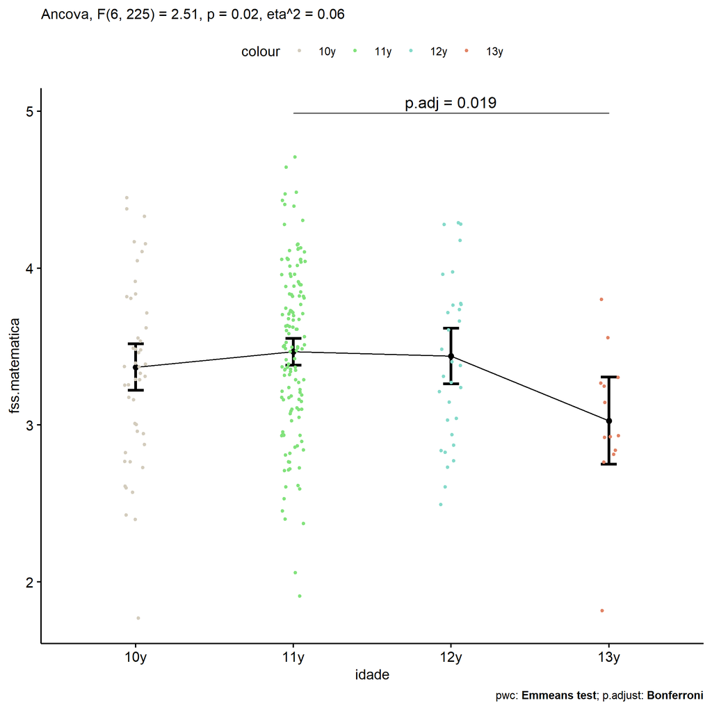

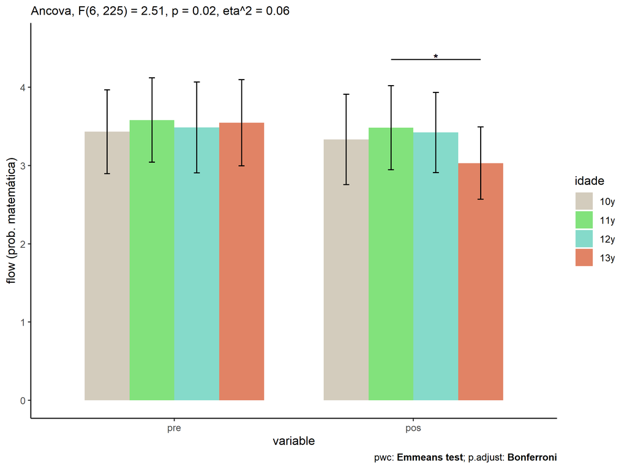

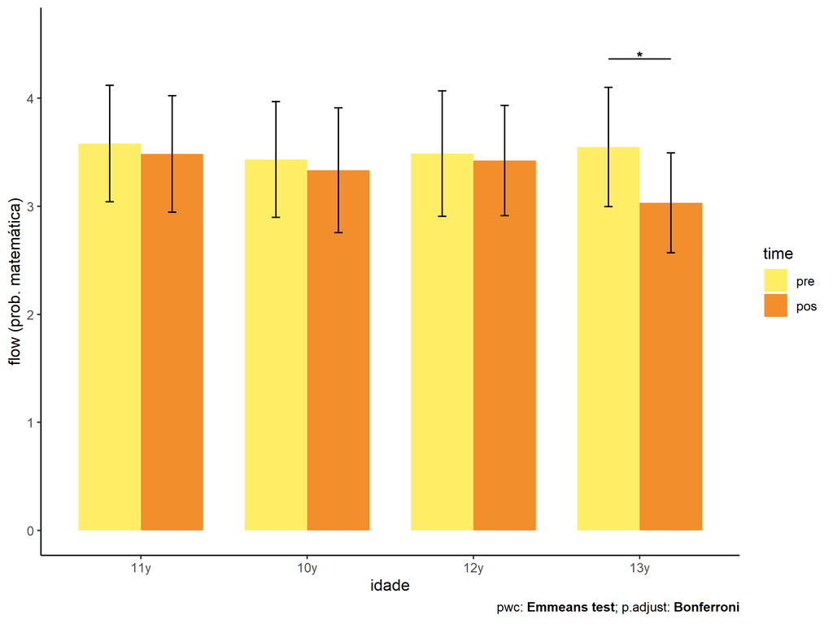

### factor: **zona.participante**

| var | zona.participante | n | M (pre) | SE (pre) | M (unadj) | SE (unadj) | M (adj) | SE (adj) |
| --- | --- | --- | --- | --- | --- | --- | --- | --- |
| fss.matematica | Rural | 91 | 3.558 | 0.059 | 3.431 | 0.054 | 3.409 | 0.055 |
| fss.matematica | Urbana | 97 | 3.414 | 0.057 | 3.367 | 0.058 | 3.389 | 0.053 |

| .y. | group1 | group2 | estimate | conf.low | conf.high | se | statistic | p | p.adj | p.adj.signif |
| --- | --- | --- | --- | --- | --- | --- | --- | --- | --- | --- |
| fss.matematica | Urbana | Rural | -0.020 | -0.171 | 0.131 | 0.077 | -0.259 | 0.796 | 0.796 | ns |
| dfs.matematica | Urbana | Rural | -0.144 | -0.306 | 0.018 | 0.082 | -1.756 | 0.081 | 0.081 | ns |

| .y. | zona.participante | group1 | group2 | estimate | conf.low | conf.high | se | statistic | p | p.adj | p.adj.signif |
| --- | --- | --- | --- | --- | --- | --- | --- | --- | --- | --- | --- |
| flow.matematica | Urbana | pre | pos | 0.047 | -0.110 | 0.203 | 0.080 | 0.585 | 0.559 | 0.559 | ns |
| flow.matematica | Rural | pre | pos | 0.127 | -0.035 | 0.289 | 0.082 | 1.542 | 0.124 | 0.124 | ns |

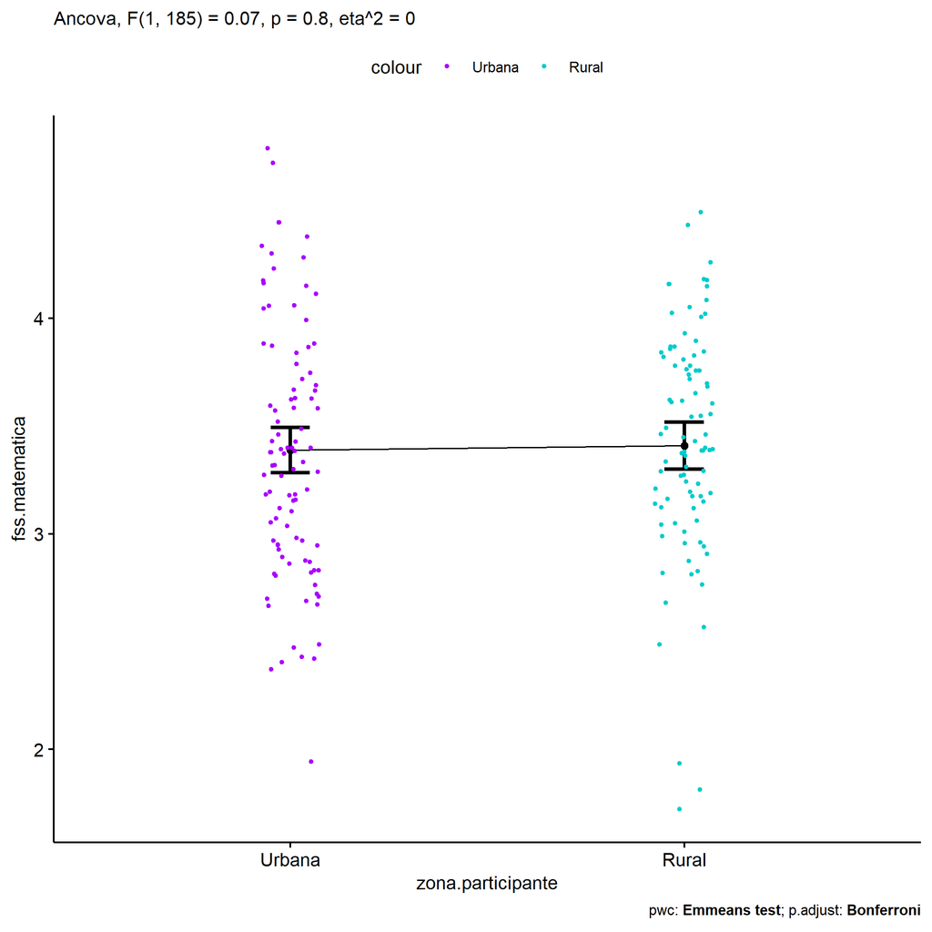

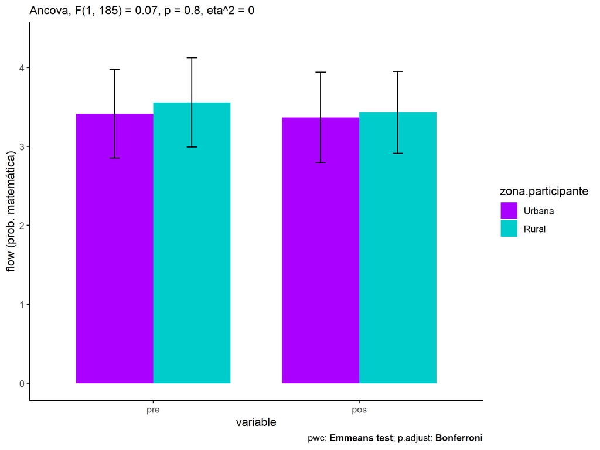

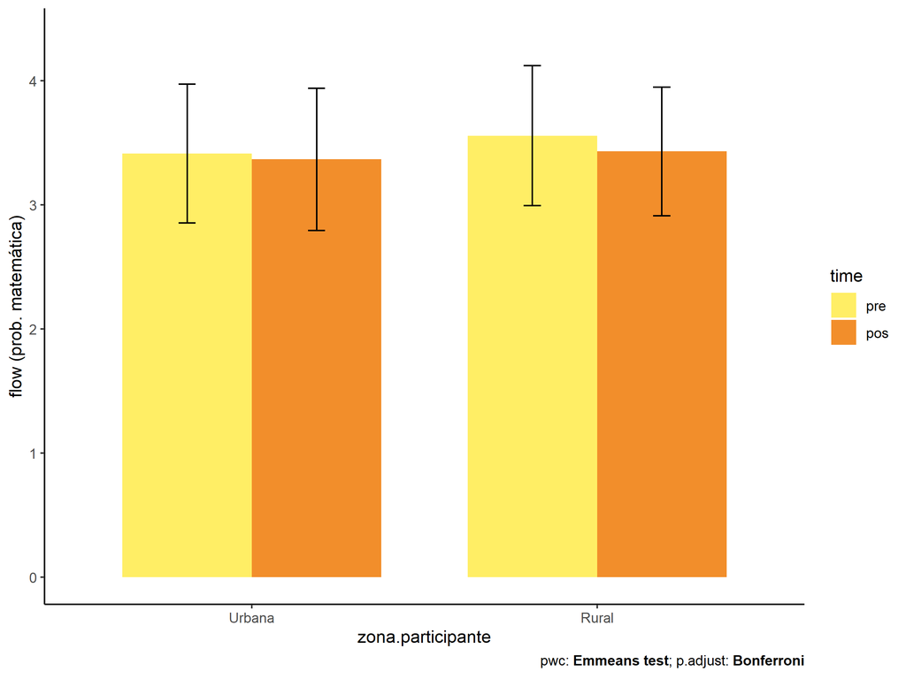

### factor: **escola**

| var | escola | n | M (pre) | SE (pre) | M (unadj) | SE (unadj) | M (adj) | SE (adj) |
| --- | --- | --- | --- | --- | --- | --- | --- | --- |
| fss.matematica | E1 | 22 | 3.203 | 0.109 | 3.431 | 0.140 | 3.542 | 0.112 |
| fss.matematica | E2 | 47 | 3.492 | 0.075 | 3.311 | 0.075 | 3.322 | 0.075 |
| fss.matematica | E3 | 30 | 3.658 | 0.115 | 3.340 | 0.082 | 3.293 | 0.094 |
| fss.matematica | E4 | 25 | 3.654 | 0.082 | 3.476 | 0.086 | 3.431 | 0.103 |
| fss.matematica | E5 | 95 | 3.487 | 0.059 | 3.441 | 0.062 | 3.453 | 0.053 |
| fss.matematica | E6 | 22 | 3.742 | 0.090 | 3.601 | 0.097 | 3.525 | 0.111 |

| .y. | group1 | group2 | estimate | conf.low | conf.high | se | statistic | p | p.adj | p.adj.signif |
| --- | --- | --- | --- | --- | --- | --- | --- | --- | --- | --- |
| fss.matematica | E1 | E2 | 0.221 | -0.044 | 0.485 | 0.134 | 1.646 | 0.101 | 1.000 | ns |
| fss.matematica | E1 | E3 | 0.249 | -0.041 | 0.539 | 0.147 | 1.692 | 0.092 | 1.000 | ns |
| fss.matematica | E1 | E4 | 0.112 | -0.190 | 0.413 | 0.153 | 0.730 | 0.466 | 1.000 | ns |
| fss.matematica | E1 | E5 | 0.089 | -0.153 | 0.331 | 0.123 | 0.723 | 0.470 | 1.000 | ns |
| fss.matematica | E1 | E6 | 0.017 | -0.296 | 0.330 | 0.159 | 0.108 | 0.914 | 1.000 | ns |
| fss.matematica | E2 | E3 | 0.028 | -0.210 | 0.266 | 0.121 | 0.234 | 0.815 | 1.000 | ns |
| fss.matematica | E2 | E4 | -0.109 | -0.361 | 0.143 | 0.128 | -0.853 | 0.394 | 1.000 | ns |
| fss.matematica | E2 | E5 | -0.132 | -0.313 | 0.049 | 0.092 | -1.436 | 0.152 | 1.000 | ns |
| fss.matematica | E2 | E6 | -0.204 | -0.467 | 0.060 | 0.134 | -1.521 | 0.130 | 1.000 | ns |
| fss.matematica | E3 | E4 | -0.137 | -0.412 | 0.137 | 0.139 | -0.985 | 0.326 | 1.000 | ns |
| fss.matematica | E3 | E5 | -0.160 | -0.373 | 0.053 | 0.108 | -1.478 | 0.141 | 1.000 | ns |
| fss.matematica | E3 | E6 | -0.232 | -0.517 | 0.053 | 0.145 | -1.604 | 0.110 | 1.000 | ns |
| fss.matematica | E4 | E5 | -0.023 | -0.252 | 0.206 | 0.116 | -0.196 | 0.845 | 1.000 | ns |
| fss.matematica | E4 | E6 | -0.095 | -0.391 | 0.202 | 0.151 | -0.628 | 0.530 | 1.000 | ns |
| fss.matematica | E5 | E6 | -0.072 | -0.314 | 0.170 | 0.123 | -0.585 | 0.559 | 1.000 | ns |
| dfs.matematica | E1 | E2 | -0.288 | -0.562 | -0.015 | 0.139 | -2.077 | 0.039 | 0.583 | ns |
| dfs.matematica | E1 | E3 | -0.454 | -0.752 | -0.157 | 0.151 | -3.011 | 0.003 | 0.043 | * |
| dfs.matematica | E1 | E4 | -0.451 | -0.761 | -0.142 | 0.157 | -2.871 | 0.004 | 0.067 | ns |
| dfs.matematica | E1 | E5 | -0.284 | -0.534 | -0.033 | 0.127 | -2.229 | 0.027 | 0.401 | ns |
| dfs.matematica | E1 | E6 | -0.539 | -0.858 | -0.220 | 0.162 | -3.326 | 0.001 | 0.015 | * |
| dfs.matematica | E2 | E3 | -0.166 | -0.414 | 0.082 | 0.126 | -1.321 | 0.188 | 1.000 | ns |
| dfs.matematica | E2 | E4 | -0.163 | -0.425 | 0.099 | 0.133 | -1.223 | 0.223 | 1.000 | ns |
| dfs.matematica | E2 | E5 | 0.005 | -0.184 | 0.194 | 0.096 | 0.051 | 0.959 | 1.000 | ns |
| dfs.matematica | E2 | E6 | -0.251 | -0.524 | 0.023 | 0.139 | -1.805 | 0.072 | 1.000 | ns |
| dfs.matematica | E3 | E4 | 0.003 | -0.284 | 0.290 | 0.146 | 0.023 | 0.982 | 1.000 | ns |
| dfs.matematica | E3 | E5 | 0.171 | -0.051 | 0.393 | 0.113 | 1.518 | 0.130 | 1.000 | ns |
| dfs.matematica | E3 | E6 | -0.085 | -0.382 | 0.213 | 0.151 | -0.561 | 0.575 | 1.000 | ns |
| dfs.matematica | E4 | E5 | 0.168 | -0.070 | 0.406 | 0.121 | 1.387 | 0.167 | 1.000 | ns |
| dfs.matematica | E4 | E6 | -0.088 | -0.398 | 0.222 | 0.157 | -0.560 | 0.576 | 1.000 | ns |
| dfs.matematica | E5 | E6 | -0.256 | -0.506 | -0.005 | 0.127 | -2.009 | 0.046 | 0.685 | ns |

| .y. | escola | group1 | group2 | estimate | conf.low | conf.high | se | statistic | p | p.adj | p.adj.signif |
| --- | --- | --- | --- | --- | --- | --- | --- | --- | --- | --- | --- |
| flow.matematica | E1 | pre | pos | -0.228 | -0.549 | 0.093 | 0.163 | -1.396 | 0.163 | 0.163 | ns |
| flow.matematica | E2 | pre | pos | 0.181 | -0.039 | 0.401 | 0.112 | 1.620 | 0.106 | 0.106 | ns |
| flow.matematica | E3 | pre | pos | 0.318 | 0.043 | 0.593 | 0.140 | 2.272 | 0.024 | 0.024 | * |
| flow.matematica | E4 | pre | pos | 0.178 | -0.123 | 0.480 | 0.153 | 1.165 | 0.245 | 0.245 | ns |
| flow.matematica | E5 | pre | pos | 0.046 | -0.108 | 0.201 | 0.079 | 0.587 | 0.557 | 0.557 | ns |
| flow.matematica | E6 | pre | pos | 0.141 | -0.180 | 0.462 | 0.163 | 0.865 | 0.387 | 0.387 | ns |

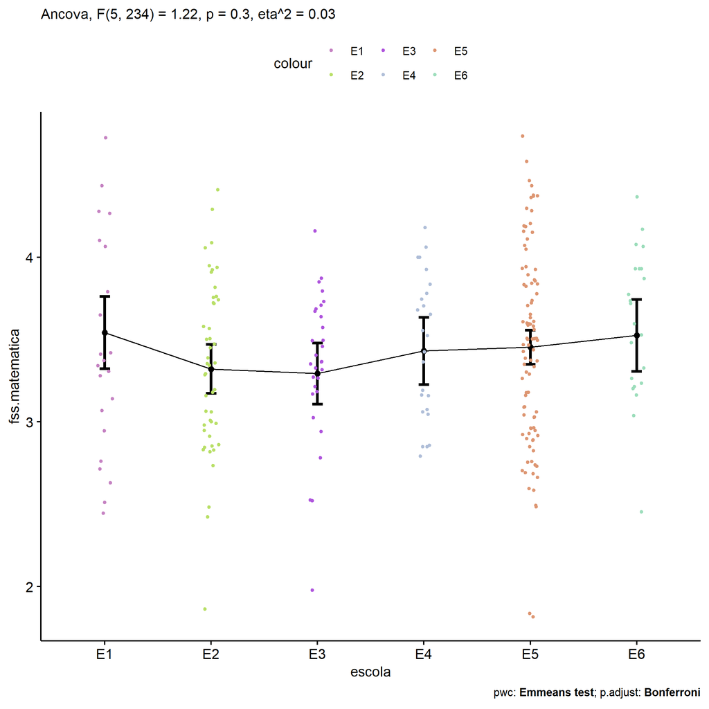

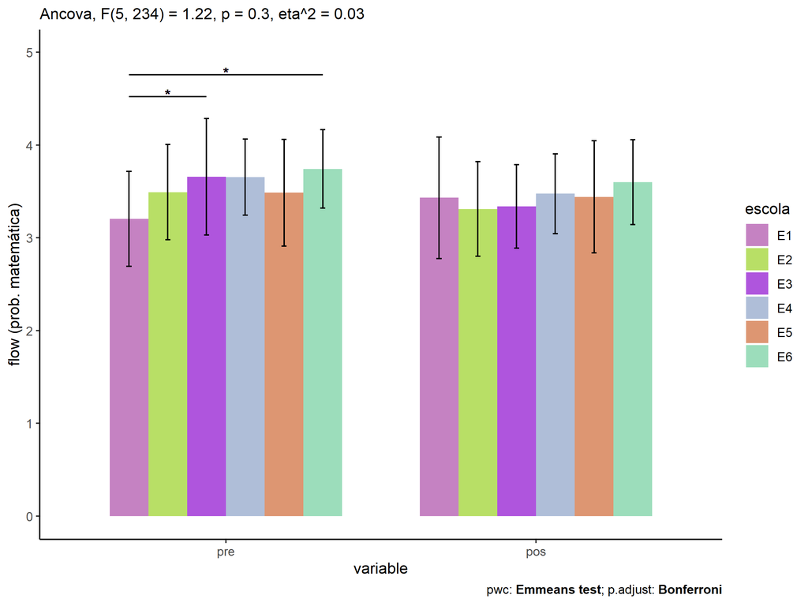

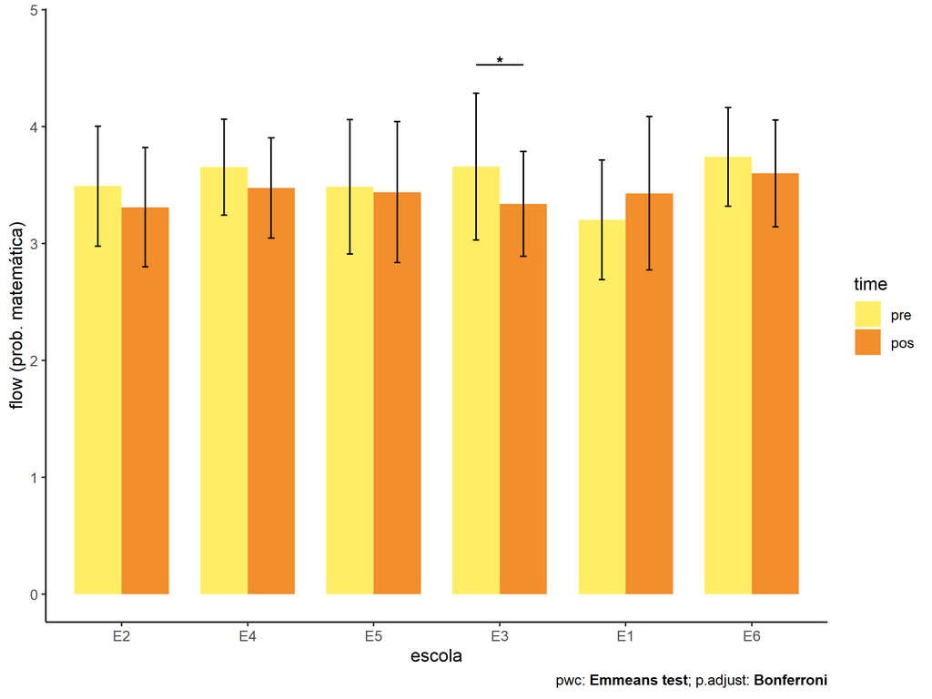

### factor: **zona.escola**

| var | zona.escola | n | M (pre) | SE (pre) | M (unadj) | SE (unadj) | M (adj) | SE (adj) |
| --- | --- | --- | --- | --- | --- | --- | --- | --- |
| fss.matematica | Rural | 77 | 3.681 | 0.057 | 3.459 | 0.052 | 3.405 | 0.060 |
| fss.matematica | Urbana | 164 | 3.450 | 0.043 | 3.402 | 0.046 | 3.427 | 0.041 |

| .y. | group1 | group2 | estimate | conf.low | conf.high | se | statistic | p | p.adj | p.adj.signif |
| --- | --- | --- | --- | --- | --- | --- | --- | --- | --- | --- |
| fss.matematica | Urbana | Rural | 0.022 | -0.122 | 0.165 | 0.073 | 0.297 | 0.766 | 0.766 | ns |
| dfs.matematica | Urbana | Rural | -0.231 | -0.378 | -0.084 | 0.075 | -3.094 | 0.002 | 0.002 | ** |

| .y. | zona.escola | group1 | group2 | estimate | conf.low | conf.high | se | statistic | p | p.adj | p.adj.signif |
| --- | --- | --- | --- | --- | --- | --- | --- | --- | --- | --- | --- |
| flow.matematica | Urbana | pre | pos | 0.048 | -0.07 | 0.166 | 0.060 | 0.801 | 0.424 | 0.424 | ns |
| flow.matematica | Rural | pre | pos | 0.222 | 0.05 | 0.394 | 0.088 | 2.538 | 0.011 | 0.011 | * |

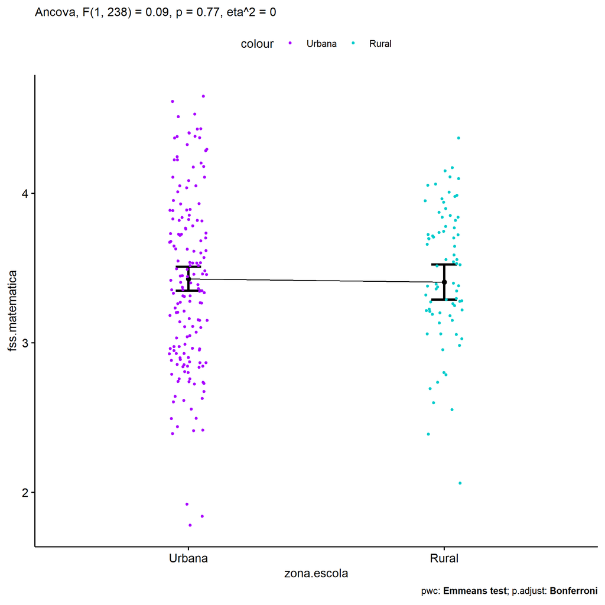

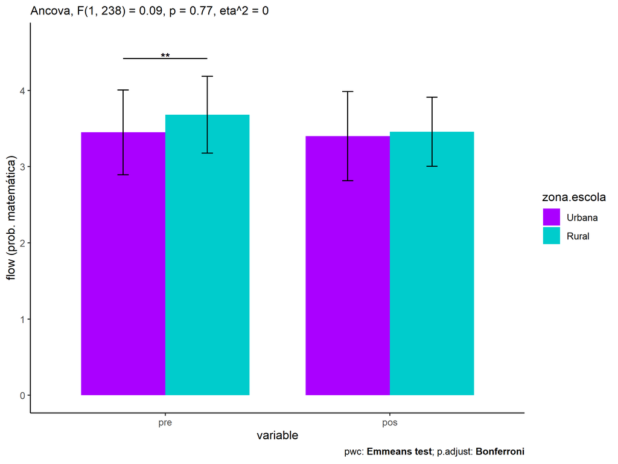

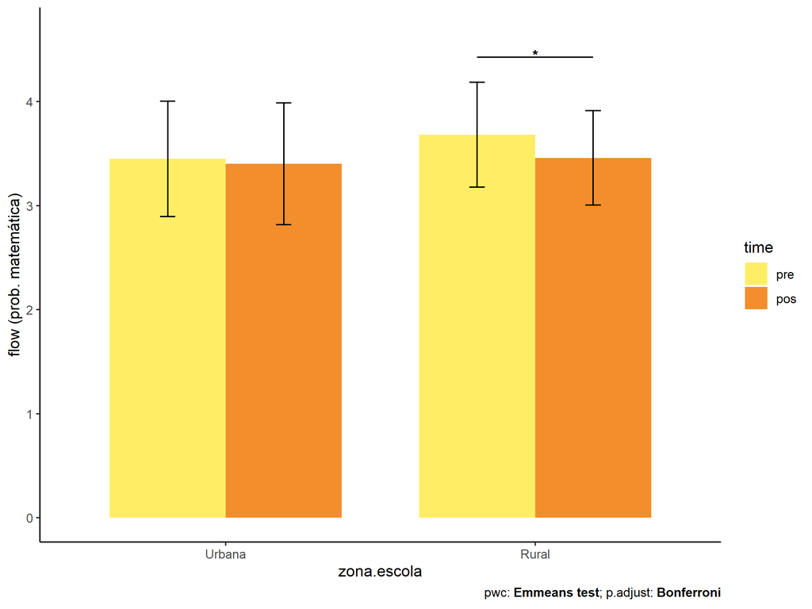